# Risk Factor Analysis

## Outcome Variable

**Outcome Variable:** stunted

## Predictor Variables

**Intervention Variable:** anywast06

**Adjustment Set:**

- arm
- sex
- brthmon
- W_mage
- meducyrs
- hhwealth_quart
- W_nrooms
- month
- W_parity
- delta_W_mage
- delta_meducyrs
- delta_hhwealth_quart
- delta_W_nrooms
- delta_month
- delta_W_parity

## Stratifying Variables

The analysis was stratified on these variable(s):

- agecat
- studyid
- country

## Data Summary

| agecat | studyid | country | anywast06 | stunted | n_cell | n |
| --- | --- | --- | --- | --- | --- | --- |
| Birth | ki0047075b-MAL-ED | BANGLADESH | 0 | 0 | 146 | 229 |
| Birth | ki0047075b-MAL-ED | BANGLADESH | 0 | 1 | 31 | 229 |
| Birth | ki0047075b-MAL-ED | BANGLADESH | 1 | 0 | 41 | 229 |
| Birth | ki0047075b-MAL-ED | BANGLADESH | 1 | 1 | 11 | 229 |
| Birth | ki0047075b-MAL-ED | BRAZIL | 0 | 0 | 53 | 65 |
| Birth | ki0047075b-MAL-ED | BRAZIL | 0 | 1 | 9 | 65 |
| Birth | ki0047075b-MAL-ED | BRAZIL | 1 | 0 | 3 | 65 |
| Birth | ki0047075b-MAL-ED | BRAZIL | 1 | 1 | 0 | 65 |
| Birth | ki0047075b-MAL-ED | INDIA | 0 | 0 | 25 | 47 |
| Birth | ki0047075b-MAL-ED | INDIA | 0 | 1 | 8 | 47 |
| Birth | ki0047075b-MAL-ED | INDIA | 1 | 0 | 12 | 47 |
| Birth | ki0047075b-MAL-ED | INDIA | 1 | 1 | 2 | 47 |
| Birth | ki0047075b-MAL-ED | NEPAL | 0 | 0 | 22 | 27 |
| Birth | ki0047075b-MAL-ED | NEPAL | 0 | 1 | 1 | 27 |
| Birth | ki0047075b-MAL-ED | NEPAL | 1 | 0 | 3 | 27 |
| Birth | ki0047075b-MAL-ED | NEPAL | 1 | 1 | 1 | 27 |
| Birth | ki0047075b-MAL-ED | PERU | 0 | 0 | 199 | 233 |
| Birth | ki0047075b-MAL-ED | PERU | 0 | 1 | 24 | 233 |
| Birth | ki0047075b-MAL-ED | PERU | 1 | 0 | 8 | 233 |
| Birth | ki0047075b-MAL-ED | PERU | 1 | 1 | 2 | 233 |
| Birth | ki0047075b-MAL-ED | SOUTH AFRICA | 0 | 0 | 93 | 122 |
| Birth | ki0047075b-MAL-ED | SOUTH AFRICA | 0 | 1 | 8 | 122 |
| Birth | ki0047075b-MAL-ED | SOUTH AFRICA | 1 | 0 | 20 | 122 |
| Birth | ki0047075b-MAL-ED | SOUTH AFRICA | 1 | 1 | 1 | 122 |
| Birth | ki0047075b-MAL-ED | TANZANIA, UNITED REPUBLIC OF | 0 | 0 | 99 | 124 |
| Birth | ki0047075b-MAL-ED | TANZANIA, UNITED REPUBLIC OF | 0 | 1 | 20 | 124 |
| Birth | ki0047075b-MAL-ED | TANZANIA, UNITED REPUBLIC OF | 1 | 0 | 3 | 124 |
| Birth | ki0047075b-MAL-ED | TANZANIA, UNITED REPUBLIC OF | 1 | 1 | 2 | 124 |
| Birth | ki1000108-CMC-V-BCS-2002 | INDIA | 0 | 0 | 30 | 92 |
| Birth | ki1000108-CMC-V-BCS-2002 | INDIA | 0 | 1 | 7 | 92 |

[output cut: 170 more lines]

The following strata were considered:

- agecat: 24 months, studyid: ki0047075b-MAL-ED, country: BANGLADESH
- agecat: 24 months, studyid: ki0047075b-MAL-ED, country: BRAZIL
- agecat: 24 months, studyid: ki0047075b-MAL-ED, country: INDIA
- agecat: 24 months, studyid: ki0047075b-MAL-ED, country: NEPAL
- agecat: 24 months, studyid: ki0047075b-MAL-ED, country: PERU
- agecat: 24 months, studyid: ki0047075b-MAL-ED, country: SOUTH AFRICA
- agecat: 24 months, studyid: ki0047075b-MAL-ED, country: TANZANIA, UNITED REPUBLIC OF
- agecat: 24 months, studyid: ki1000108-CMC-V-BCS-2002, country: INDIA
- agecat: 24 months, studyid: ki1000108-IRC, country: INDIA
- agecat: 24 months, studyid: ki1000109-EE, country: PAKISTAN
- agecat: 24 months, studyid: ki1017093b-PROVIDE, country: BANGLADESH
- agecat: 24 months, studyid: ki1066203-TanzaniaChild2, country: TANZANIA, UNITED REPUBLIC OF
- agecat: 24 months, studyid: ki1101329-Keneba, country: GAMBIA
- agecat: 24 months, studyid: ki1113344-GMS-Nepal, country: NEPAL
- agecat: 24 months, studyid: ki1114097-CMIN, country: BANGLADESH
- agecat: 24 months, studyid: ki1114097-CONTENT, country: PERU
- agecat: 6 months, studyid: ki0047075b-MAL-ED, country: BANGLADESH
- agecat: 6 months, studyid: ki0047075b-MAL-ED, country: BRAZIL
- agecat: 6 months, studyid: ki0047075b-MAL-ED, country: INDIA
- agecat: 6 months, studyid: ki0047075b-MAL-ED, country: NEPAL
- agecat: 6 months, studyid: ki0047075b-MAL-ED, country: PERU
- agecat: 6 months, studyid: ki0047075b-MAL-ED, country: SOUTH AFRICA
- agecat: 6 months, studyid: ki0047075b-MAL-ED, country: TANZANIA, UNITED REPUBLIC OF
- agecat: 6 months, studyid: ki1000108-CMC-V-BCS-2002, country: INDIA
- agecat: 6 months, studyid: ki1000108-IRC, country: INDIA
- agecat: 6 months, studyid: ki1000109-EE, country: PAKISTAN
- agecat: 6 months, studyid: ki1000109-ResPak, country: PAKISTAN
- agecat: 6 months, studyid: ki1017093b-PROVIDE, country: BANGLADESH
- agecat: 6 months, studyid: ki1066203-TanzaniaChild2, country: TANZANIA, UNITED REPUBLIC OF
- agecat: 6 months, studyid: ki1101329-Keneba, country: GAMBIA
- agecat: 6 months, studyid: ki1112895-Guatemala BSC, country: GUATEMALA
- agecat: 6 months, studyid: ki1113344-GMS-Nepal, country: NEPAL
- agecat: 6 months, studyid: ki1114097-CMIN, country: BANGLADESH
- agecat: 6 months, studyid: ki1114097-CONTENT, country: PERU
- agecat: Birth, studyid: ki0047075b-MAL-ED, country: BANGLADESH
- agecat: Birth, studyid: ki0047075b-MAL-ED, country: BRAZIL
- agecat: Birth, studyid: ki0047075b-MAL-ED, country: INDIA
- agecat: Birth, studyid: ki0047075b-MAL-ED, country: NEPAL
- agecat: Birth, studyid: ki0047075b-MAL-ED, country: PERU
- agecat: Birth, studyid: ki0047075b-MAL-ED, country: SOUTH AFRICA
- agecat: Birth, studyid: ki0047075b-MAL-ED, country: TANZANIA, UNITED REPUBLIC OF
- agecat: Birth, studyid: ki1000108-CMC-V-BCS-2002, country: INDIA
- agecat: Birth, studyid: ki1000108-IRC, country: INDIA
- agecat: Birth, studyid: ki1000109-EE, country: PAKISTAN
- agecat: Birth, studyid: ki1000109-ResPak, country: PAKISTAN
- agecat: Birth, studyid: ki1017093b-PROVIDE, country: BANGLADESH
- agecat: Birth, studyid: ki1101329-Keneba, country: GAMBIA
- agecat: Birth, studyid: ki1113344-GMS-Nepal, country: NEPAL
- agecat: Birth, studyid: ki1114097-CMIN, country: BANGLADESH
- agecat: Birth, studyid: ki1114097-CONTENT, country: PERU

### Dropped Strata

Some strata were dropped due to rare outcomes:

- agecat: Birth, studyid: ki0047075b-MAL-ED, country: BRAZIL
- agecat: Birth, studyid: ki0047075b-MAL-ED, country: INDIA
- agecat: Birth, studyid: ki0047075b-MAL-ED, country: NEPAL
- agecat: Birth, studyid: ki0047075b-MAL-ED, country: PERU
- agecat: Birth, studyid: ki0047075b-MAL-ED, country: SOUTH AFRICA
- agecat: Birth, studyid: ki0047075b-MAL-ED, country: TANZANIA, UNITED REPUBLIC OF
- agecat: Birth, studyid: ki1000109-ResPak, country: PAKISTAN
- agecat: Birth, studyid: ki1114097-CMIN, country: BANGLADESH
- agecat: Birth, studyid: ki1114097-CONTENT, country: PERU
- agecat: 6 months, studyid: ki0047075b-MAL-ED, country: BRAZIL
- agecat: 6 months, studyid: ki0047075b-MAL-ED, country: PERU
- agecat: 6 months, studyid: ki0047075b-MAL-ED, country: TANZANIA, UNITED REPUBLIC OF
- agecat: 6 months, studyid: ki1112895-Guatemala BSC, country: GUATEMALA
- agecat: 6 months, studyid: ki1114097-CONTENT, country: PERU
- agecat: 24 months, studyid: ki0047075b-MAL-ED, country: BRAZIL
- agecat: 24 months, studyid: ki0047075b-MAL-ED, country: PERU
- agecat: 24 months, studyid: ki0047075b-MAL-ED, country: TANZANIA, UNITED REPUBLIC OF
- agecat: 24 months, studyid: ki1066203-TanzaniaChild2, country: TANZANIA, UNITED REPUBLIC OF
- agecat: 24 months, studyid: ki1114097-CONTENT, country: PERU

## Methods Detail

We’re interested in the causal parameters $E[Y_a]$ for all values of $a \in \mathcal{A}$. These parameters represent the mean outcome if, possibly contrary to fact, we intervened to set all units to have $A=a$. Under the randomization and positivity assumptions, these are identified by the statistical parameters $\psi_a=E_W[E_{Y|A,W}(Y|A=a,W)]$. In addition, we’re interested in the mean of $Y$, $E[Y]$ under no intervention (the observed mean). We will estimate these parameters by using SuperLearner to fit the relevant likelihood factors – $E_{Y|A,W}(Y|A=a,W)$ and $p(A=a|W)$, and then updating our likelihood fit using a joint TMLE.

For unadjusted analyses ($W=\{\}$), initial likelihoods were estimated using Lrnr_glm to estimate the simple $E(Y|A)$ and Lrnr_mean to estimate $p(A)$. For adjusted analyses, a small library containing Lrnr_glmnet, Lrnr_xgboost, and Lrnr_mean was used.

Having estimated these parameters, we will then use the delta method to estimate relative risks and attributable risks relative to a prespecified baseline level of $A$.

# Results Detail

## Results Plots

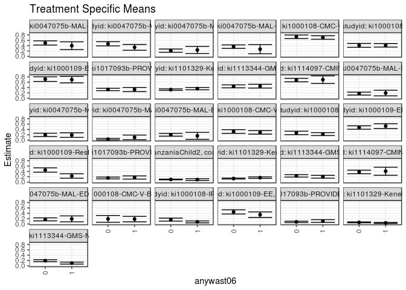

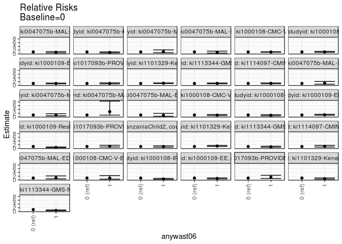

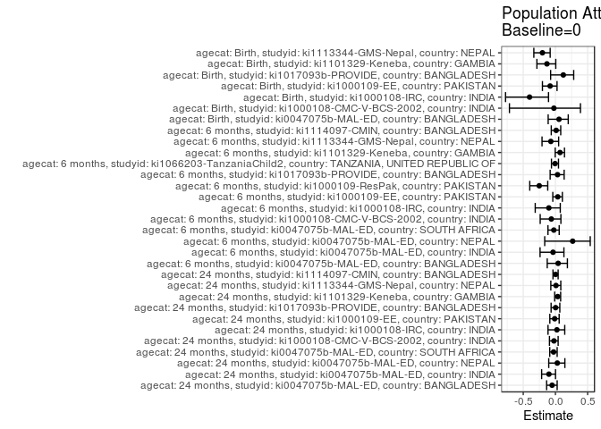

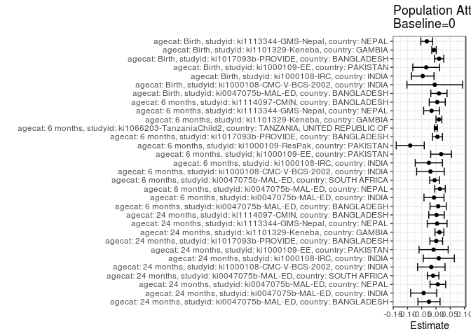

## Results Table

### Parameter: TSM

| agecat | studyid | country | intervention_level | baseline_level | estimate | ci_lower | ci_upper |
| --- | --- | --- | --- | --- | --- | --- | --- |
| Birth | ki0047075b-MAL-ED | BANGLADESH | 0 | NA | 0.1731685 | 0.1170158 | 0.2293212 |
| Birth | ki0047075b-MAL-ED | BANGLADESH | 1 | NA | 0.1905814 | 0.0799171 | 0.3012456 |
| Birth | ki1000108-CMC-V-BCS-2002 | INDIA | 0 | NA | 0.1891892 | 0.0622989 | 0.3160795 |
| Birth | ki1000108-CMC-V-BCS-2002 | INDIA | 1 | NA | 0.1818182 | 0.0793277 | 0.2843087 |
| Birth | ki1000108-IRC | INDIA | 0 | NA | 0.1625756 | 0.1058644 | 0.2192868 |
| Birth | ki1000108-IRC | INDIA | 1 | NA | 0.0789773 | 0.0432095 | 0.1147451 |
| Birth | ki1000109-EE | PAKISTAN | 0 | NA | 0.4510331 | 0.3717725 | 0.5302937 |
| Birth | ki1000109-EE | PAKISTAN | 1 | NA | 0.3459205 | 0.2418699 | 0.4499710 |
| Birth | ki1017093b-PROVIDE | BANGLADESH | 0 | NA | 0.0781366 | 0.0518762 | 0.1043970 |
| Birth | ki1017093b-PROVIDE | BANGLADESH | 1 | NA | 0.1092439 | 0.0571651 | 0.1613227 |
| Birth | ki1101329-Keneba | GAMBIA | 0 | NA | 0.0601839 | 0.0453659 | 0.0750018 |
| Birth | ki1101329-Keneba | GAMBIA | 1 | NA | 0.0395856 | 0.0230989 | 0.0560724 |
| Birth | ki1113344-GMS-Nepal | NEPAL | 0 | NA | 0.1932869 | 0.1554820 | 0.2310919 |
| Birth | ki1113344-GMS-Nepal | NEPAL | 1 | NA | 0.1035345 | 0.0659231 | 0.1411459 |
| 6 months | ki0047075b-MAL-ED | BANGLADESH | 0 | NA | 0.1749204 | 0.1196501 | 0.2301908 |
| 6 months | ki0047075b-MAL-ED | BANGLADESH | 1 | NA | 0.1949566 | 0.0899462 | 0.2999670 |
| 6 months | ki0047075b-MAL-ED | INDIA | 0 | NA | 0.1977438 | 0.1358193 | 0.2596683 |
| 6 months | ki0047075b-MAL-ED | INDIA | 1 | NA | 0.1898691 | 0.1042069 | 0.2755313 |
| 6 months | ki0047075b-MAL-ED | NEPAL | 0 | NA | 0.0372340 | 0.0101120 | 0.0643560 |
| 6 months | ki0047075b-MAL-ED | NEPAL | 1 | NA | 0.1041667 | 0.0175647 | 0.1907686 |
| 6 months | ki0047075b-MAL-ED | SOUTH AFRICA | 0 | NA | 0.2017937 | 0.1490144 | 0.2545730 |
| 6 months | ki0047075b-MAL-ED | SOUTH AFRICA | 1 | NA | 0.1612903 | 0.0315623 | 0.2910184 |
| 6 months | ki1000108-CMC-V-BCS-2002 | INDIA | 0 | NA | 0.3235250 | 0.2553631 | 0.3916869 |
| 6 months | ki1000108-CMC-V-BCS-2002 | INDIA | 1 | NA | 0.2924909 | 0.2273292 | 0.3576526 |
| 6 months | ki1000108-IRC | INDIA | 0 | NA | 0.2708558 | 0.2055932 | 0.3361184 |
| 6 months | ki1000108-IRC | INDIA | 1 | NA | 0.2256834 | 0.1708986 | 0.2804682 |
| 6 months | ki1000109-EE | PAKISTAN | 0 | NA | 0.4728146 | 0.4102919 | 0.5353373 |
| 6 months | ki1000109-EE | PAKISTAN | 1 | NA | 0.5254274 | 0.4364198 | 0.6144349 |
| 6 months | ki1000109-ResPak | PAKISTAN | 0 | NA | 0.4502695 | 0.3683337 | 0.5322053 |
| 6 months | ki1000109-ResPak | PAKISTAN | 1 | NA | 0.2280155 | 0.1441271 | 0.3119038 |
| 6 months | ki1017093b-PROVIDE | BANGLADESH | 0 | NA | 0.1537406 | 0.1206860 | 0.1867952 |
| 6 months | ki1017093b-PROVIDE | BANGLADESH | 1 | NA | 0.1710847 | 0.1110966 | 0.2310728 |
| 6 months | ki1066203-TanzaniaChild2 | TANZANIA, UNITED REPUBLIC OF | 0 | NA | 0.0976375 | 0.0836439 | 0.1116312 |
| 6 months | ki1066203-TanzaniaChild2 | TANZANIA, UNITED REPUBLIC OF | 1 | NA | 0.0931928 | 0.0601318 | 0.1262538 |
| 6 months | ki1101329-Keneba | GAMBIA | 0 | NA | 0.1318888 | 0.1144391 | 0.1493385 |
| 6 months | ki1101329-Keneba | GAMBIA | 1 | NA | 0.1648252 | 0.1354895 | 0.1941610 |
| 6 months | ki1113344-GMS-Nepal | NEPAL | 0 | NA | 0.2317681 | 0.1868131 | 0.2767232 |
| 6 months | ki1113344-GMS-Nepal | NEPAL | 1 | NA | 0.1983622 | 0.1462513 | 0.2504731 |
| 6 months | ki1114097-CMIN | BANGLADESH | 0 | NA | 0.3783508 | 0.3110078 | 0.4456939 |
| 6 months | ki1114097-CMIN | BANGLADESH | 1 | NA | 0.4039772 | 0.2531495 | 0.5548049 |
| 24 months | ki0047075b-MAL-ED | BANGLADESH | 0 | NA | 0.5010354 | 0.4230918 | 0.5789791 |
| 24 months | ki0047075b-MAL-ED | BANGLADESH | 1 | NA | 0.3977848 | 0.2526189 | 0.5429507 |
| 24 months | ki0047075b-MAL-ED | INDIA | 0 | NA | 0.4705129 | 0.3907060 | 0.5503199 |
| 24 months | ki0047075b-MAL-ED | INDIA | 1 | NA | 0.3358689 | 0.2277586 | 0.4439793 |
| 24 months | ki0047075b-MAL-ED | NEPAL | 0 | NA | 0.2128498 | 0.1531748 | 0.2725247 |
| 24 months | ki0047075b-MAL-ED | NEPAL | 1 | NA | 0.2387710 | 0.1062840 | 0.3712580 |
| 24 months | ki0047075b-MAL-ED | SOUTH AFRICA | 0 | NA | 0.3632075 | 0.2983335 | 0.4280816 |
| 24 months | ki0047075b-MAL-ED | SOUTH AFRICA | 1 | NA | 0.2692308 | 0.0983756 | 0.4400860 |
| 24 months | ki1000108-CMC-V-BCS-2002 | INDIA | 0 | NA | 0.7323720 | 0.6664182 | 0.7983258 |
| 24 months | ki1000108-CMC-V-BCS-2002 | INDIA | 1 | NA | 0.7040498 | 0.6390148 | 0.7690848 |
| 24 months | ki1000108-IRC | INDIA | 0 | NA | 0.4107038 | 0.3382264 | 0.4831811 |
| 24 months | ki1000108-IRC | INDIA | 1 | NA | 0.4116369 | 0.3474678 | 0.4758059 |
| 24 months | ki1000109-EE | PAKISTAN | 0 | NA | 0.7150396 | 0.6292234 | 0.8008558 |
| 24 months | ki1000109-EE | PAKISTAN | 1 | NA | 0.6956445 | 0.5739296 | 0.8173595 |
| 24 months | ki1017093b-PROVIDE | BANGLADESH | 0 | NA | 0.3278527 | 0.2834875 | 0.3722180 |
| 24 months | ki1017093b-PROVIDE | BANGLADESH | 1 | NA | 0.3268902 | 0.2505829 | 0.4031975 |
| 24 months | ki1101329-Keneba | GAMBIA | 0 | NA | 0.3226956 | 0.2949201 | 0.3504712 |
| 24 months | ki1101329-Keneba | GAMBIA | 1 | NA | 0.3602125 | 0.3171533 | 0.4032718 |
| 24 months | ki1113344-GMS-Nepal | NEPAL | 0 | NA | 0.4448183 | 0.3886231 | 0.5010134 |
| 24 months | ki1113344-GMS-Nepal | NEPAL | 1 | NA | 0.4517717 | 0.3807378 | 0.5228055 |
| 24 months | ki1114097-CMIN | BANGLADESH | 0 | NA | 0.6799252 | 0.6148454 | 0.7450049 |
| 24 months | ki1114097-CMIN | BANGLADESH | 1 | NA | 0.6947211 | 0.5511934 | 0.8382488 |

### Parameter: E(Y)

| agecat | studyid | country | intervention_level | baseline_level | estimate | ci_lower | ci_upper |
| --- | --- | --- | --- | --- | --- | --- | --- |
| Birth | ki0047075b-MAL-ED | BANGLADESH | NA | NA | 0.1834061 | 0.1331729 | 0.2336393 |
| Birth | ki1000108-CMC-V-BCS-2002 | INDIA | NA | NA | 0.1847826 | 0.1050392 | 0.2645260 |
| Birth | ki1000108-IRC | INDIA | NA | NA | 0.1159794 | 0.0840777 | 0.1478811 |
| Birth | ki1000109-EE | PAKISTAN | NA | NA | 0.4166667 | 0.3541635 | 0.4791698 |
| Birth | ki1017093b-PROVIDE | BANGLADESH | NA | NA | 0.0890538 | 0.0649864 | 0.1131212 |
| Birth | ki1101329-Keneba | GAMBIA | NA | NA | 0.0531777 | 0.0419744 | 0.0643810 |
| Birth | ki1113344-GMS-Nepal | NEPAL | NA | NA | 0.1608187 | 0.1332679 | 0.1883695 |
| 6 months | ki0047075b-MAL-ED | BANGLADESH | NA | NA | 0.1825726 | 0.1336978 | 0.2314474 |
| 6 months | ki0047075b-MAL-ED | INDIA | NA | NA | 0.1906780 | 0.1404524 | 0.2409036 |
| 6 months | ki0047075b-MAL-ED | NEPAL | NA | NA | 0.0508475 | 0.0227597 | 0.0789352 |
| 6 months | ki0047075b-MAL-ED | SOUTH AFRICA | NA | NA | 0.1968504 | 0.1478551 | 0.2458457 |
| 6 months | ki1000108-CMC-V-BCS-2002 | INDIA | NA | NA | 0.3041096 | 0.2568508 | 0.3513684 |
| 6 months | ki1000108-IRC | INDIA | NA | NA | 0.2457002 | 0.2038248 | 0.2875757 |
| 6 months | ki1000109-EE | PAKISTAN | NA | NA | 0.4906166 | 0.4398159 | 0.5414174 |
| 6 months | ki1000109-ResPak | PAKISTAN | NA | NA | 0.3598326 | 0.2988570 | 0.4208083 |
| 6 months | ki1017093b-PROVIDE | BANGLADESH | NA | NA | 0.1589404 | 0.1297581 | 0.1881227 |
| 6 months | ki1066203-TanzaniaChild2 | TANZANIA, UNITED REPUBLIC OF | NA | NA | 0.0970922 | 0.0842059 | 0.1099785 |
| 6 months | ki1101329-Keneba | GAMBIA | NA | NA | 0.1420233 | 0.1269309 | 0.1571158 |
| 6 months | ki1113344-GMS-Nepal | NEPAL | NA | NA | 0.2163121 | 0.1823021 | 0.2503220 |
| 6 months | ki1114097-CMIN | BANGLADESH | NA | NA | 0.3827160 | 0.3214780 | 0.4439541 |
| 24 months | ki0047075b-MAL-ED | BANGLADESH | NA | NA | 0.4764151 | 0.4090254 | 0.5438047 |
| 24 months | ki0047075b-MAL-ED | INDIA | NA | NA | 0.4273128 | 0.3628178 | 0.4918077 |
| 24 months | ki0047075b-MAL-ED | NEPAL | NA | NA | 0.2192982 | 0.1654718 | 0.2731246 |
| 24 months | ki0047075b-MAL-ED | SOUTH AFRICA | NA | NA | 0.3529412 | 0.2921001 | 0.4137823 |
| 24 months | ki1000108-CMC-V-BCS-2002 | INDIA | NA | NA | 0.7158470 | 0.6695782 | 0.7621158 |
| 24 months | ki1000108-IRC | INDIA | NA | NA | 0.4205379 | 0.3726382 | 0.4684376 |
| 24 months | ki1000109-EE | PAKISTAN | NA | NA | 0.7065868 | 0.6373214 | 0.7758523 |
| 24 months | ki1017093b-PROVIDE | BANGLADESH | NA | NA | 0.3287197 | 0.2903909 | 0.3670485 |
| 24 months | ki1101329-Keneba | GAMBIA | NA | NA | 0.3346129 | 0.3112129 | 0.3580129 |
| 24 months | ki1113344-GMS-Nepal | NEPAL | NA | NA | 0.4487705 | 0.4045970 | 0.4929440 |
| 24 months | ki1114097-CMIN | BANGLADESH | NA | NA | 0.6818182 | 0.6230135 | 0.7406228 |

### Parameter: RR

| agecat | studyid | country | intervention_level | baseline_level | estimate | ci_lower | ci_upper |
| --- | --- | --- | --- | --- | --- | --- | --- |
| Birth | ki0047075b-MAL-ED | BANGLADESH | 0 | 0 | 1.0000000 | 1.0000000 | 1.0000000 |
| Birth | ki0047075b-MAL-ED | BANGLADESH | 1 | 0 | 1.1005544 | 0.5650787 | 2.1434540 |
| Birth | ki1000108-CMC-V-BCS-2002 | INDIA | 0 | 0 | 1.0000000 | 1.0000000 | 1.0000000 |
| Birth | ki1000108-CMC-V-BCS-2002 | INDIA | 1 | 0 | 0.9610390 | 0.4001688 | 2.3080159 |
| Birth | ki1000108-IRC | INDIA | 0 | 0 | 1.0000000 | 1.0000000 | 1.0000000 |
| Birth | ki1000108-IRC | INDIA | 1 | 0 | 0.4857880 | 0.2738019 | 0.8619004 |
| Birth | ki1000109-EE | PAKISTAN | 0 | 0 | 1.0000000 | 1.0000000 | 1.0000000 |
| Birth | ki1000109-EE | PAKISTAN | 1 | 0 | 0.7669514 | 0.5411716 | 1.0869279 |
| Birth | ki1017093b-PROVIDE | BANGLADESH | 0 | 0 | 1.0000000 | 1.0000000 | 1.0000000 |
| Birth | ki1017093b-PROVIDE | BANGLADESH | 1 | 0 | 1.3981133 | 0.7775305 | 2.5140116 |
| Birth | ki1101329-Keneba | GAMBIA | 0 | 0 | 1.0000000 | 1.0000000 | 1.0000000 |
| Birth | ki1101329-Keneba | GAMBIA | 1 | 0 | 0.6577444 | 0.4053843 | 1.0672038 |
| Birth | ki1113344-GMS-Nepal | NEPAL | 0 | 0 | 1.0000000 | 1.0000000 | 1.0000000 |
| Birth | ki1113344-GMS-Nepal | NEPAL | 1 | 0 | 0.5356519 | 0.3544383 | 0.8095143 |
| 6 months | ki0047075b-MAL-ED | BANGLADESH | 0 | 0 | 1.0000000 | 1.0000000 | 1.0000000 |
| 6 months | ki0047075b-MAL-ED | BANGLADESH | 1 | 0 | 1.1145445 | 0.5969073 | 2.0810757 |
| 6 months | ki0047075b-MAL-ED | INDIA | 0 | 0 | 1.0000000 | 1.0000000 | 1.0000000 |
| 6 months | ki0047075b-MAL-ED | INDIA | 1 | 0 | 0.9601775 | 0.5537052 | 1.6650394 |
| 6 months | ki0047075b-MAL-ED | NEPAL | 0 | 0 | 1.0000000 | 1.0000000 | 1.0000000 |
| 6 months | ki0047075b-MAL-ED | NEPAL | 1 | 0 | 2.7976190 | 0.9262833 | 8.4495445 |
| 6 months | ki0047075b-MAL-ED | SOUTH AFRICA | 0 | 0 | 1.0000000 | 1.0000000 | 1.0000000 |
| 6 months | ki0047075b-MAL-ED | SOUTH AFRICA | 1 | 0 | 0.7992832 | 0.3430732 | 1.8621496 |
| 6 months | ki1000108-CMC-V-BCS-2002 | INDIA | 0 | 0 | 1.0000000 | 1.0000000 | 1.0000000 |
| 6 months | ki1000108-CMC-V-BCS-2002 | INDIA | 1 | 0 | 0.9040751 | 0.6656754 | 1.2278535 |
| 6 months | ki1000108-IRC | INDIA | 0 | 0 | 1.0000000 | 1.0000000 | 1.0000000 |
| 6 months | ki1000108-IRC | INDIA | 1 | 0 | 0.8332233 | 0.5920379 | 1.1726633 |
| 6 months | ki1000109-EE | PAKISTAN | 0 | 0 | 1.0000000 | 1.0000000 | 1.0000000 |
| 6 months | ki1000109-EE | PAKISTAN | 1 | 0 | 1.1112758 | 0.8958573 | 1.3784938 |
| 6 months | ki1000109-ResPak | PAKISTAN | 0 | 0 | 1.0000000 | 1.0000000 | 1.0000000 |
| 6 months | ki1000109-ResPak | PAKISTAN | 1 | 0 | 0.5063978 | 0.3366452 | 0.7617477 |
| 6 months | ki1017093b-PROVIDE | BANGLADESH | 0 | 0 | 1.0000000 | 1.0000000 | 1.0000000 |
| 6 months | ki1017093b-PROVIDE | BANGLADESH | 1 | 0 | 1.1128141 | 0.7376624 | 1.6787559 |
| 6 months | ki1066203-TanzaniaChild2 | TANZANIA, UNITED REPUBLIC OF | 0 | 0 | 1.0000000 | 1.0000000 | 1.0000000 |
| 6 months | ki1066203-TanzaniaChild2 | TANZANIA, UNITED REPUBLIC OF | 1 | 0 | 0.9544770 | 0.6510058 | 1.3994134 |
| 6 months | ki1101329-Keneba | GAMBIA | 0 | 0 | 1.0000000 | 1.0000000 | 1.0000000 |
| 6 months | ki1101329-Keneba | GAMBIA | 1 | 0 | 1.2497291 | 1.0015818 | 1.5593562 |
| 6 months | ki1113344-GMS-Nepal | NEPAL | 0 | 0 | 1.0000000 | 1.0000000 | 1.0000000 |
| 6 months | ki1113344-GMS-Nepal | NEPAL | 1 | 0 | 0.8558647 | 0.6170843 | 1.1870411 |
| 6 months | ki1114097-CMIN | BANGLADESH | 0 | 0 | 1.0000000 | 1.0000000 | 1.0000000 |
| 6 months | ki1114097-CMIN | BANGLADESH | 1 | 0 | 1.0677319 | 0.7068765 | 1.6128013 |
| 24 months | ki0047075b-MAL-ED | BANGLADESH | 0 | 0 | 1.0000000 | 1.0000000 | 1.0000000 |
| 24 months | ki0047075b-MAL-ED | BANGLADESH | 1 | 0 | 0.7939255 | 0.5338429 | 1.1807175 |
| 24 months | ki0047075b-MAL-ED | INDIA | 0 | 0 | 1.0000000 | 1.0000000 | 1.0000000 |
| 24 months | ki0047075b-MAL-ED | INDIA | 1 | 0 | 0.7138358 | 0.4960963 | 1.0271424 |
| 24 months | ki0047075b-MAL-ED | NEPAL | 0 | 0 | 1.0000000 | 1.0000000 | 1.0000000 |
| 24 months | ki0047075b-MAL-ED | NEPAL | 1 | 0 | 1.1217819 | 0.6048445 | 2.0805258 |
| 24 months | ki0047075b-MAL-ED | SOUTH AFRICA | 0 | 0 | 1.0000000 | 1.0000000 | 1.0000000 |
| 24 months | ki0047075b-MAL-ED | SOUTH AFRICA | 1 | 0 | 0.7412587 | 0.3834034 | 1.4331239 |
| 24 months | ki1000108-CMC-V-BCS-2002 | INDIA | 0 | 0 | 1.0000000 | 1.0000000 | 1.0000000 |
| 24 months | ki1000108-CMC-V-BCS-2002 | INDIA | 1 | 0 | 0.9613281 | 0.8449704 | 1.0937090 |
| 24 months | ki1000108-IRC | INDIA | 0 | 0 | 1.0000000 | 1.0000000 | 1.0000000 |
| 24 months | ki1000108-IRC | INDIA | 1 | 0 | 1.0022719 | 0.7916318 | 1.2689600 |
| 24 months | ki1000109-EE | PAKISTAN | 0 | 0 | 1.0000000 | 1.0000000 | 1.0000000 |
| 24 months | ki1000109-EE | PAKISTAN | 1 | 0 | 0.9728755 | 0.7870978 | 1.2025021 |
| 24 months | ki1017093b-PROVIDE | BANGLADESH | 0 | 0 | 1.0000000 | 1.0000000 | 1.0000000 |
| 24 months | ki1017093b-PROVIDE | BANGLADESH | 1 | 0 | 0.9970642 | 0.7614594 | 1.3055679 |
| 24 months | ki1101329-Keneba | GAMBIA | 0 | 0 | 1.0000000 | 1.0000000 | 1.0000000 |
| 24 months | ki1101329-Keneba | GAMBIA | 1 | 0 | 1.1162610 | 0.9638431 | 1.2927814 |
| 24 months | ki1113344-GMS-Nepal | NEPAL | 0 | 0 | 1.0000000 | 1.0000000 | 1.0000000 |
| 24 months | ki1113344-GMS-Nepal | NEPAL | 1 | 0 | 1.0156321 | 0.8308551 | 1.2415023 |
| 24 months | ki1114097-CMIN | BANGLADESH | 0 | 0 | 1.0000000 | 1.0000000 | 1.0000000 |
| 24 months | ki1114097-CMIN | BANGLADESH | 1 | 0 | 1.0217611 | 0.8134820 | 1.2833667 |

### Parameter: PAR

| agecat | studyid | country | intervention_level | baseline_level | estimate | ci_lower | ci_upper |
| --- | --- | --- | --- | --- | --- | --- | --- |
| Birth | ki0047075b-MAL-ED | BANGLADESH | 0 | NA | 0.0102376 | -0.0182352 | 0.0387105 |
| Birth | ki1000108-CMC-V-BCS-2002 | INDIA | 0 | NA | -0.0044066 | -0.1019219 | 0.0931087 |
| Birth | ki1000108-IRC | INDIA | 0 | NA | -0.0465962 | -0.0861129 | -0.0070795 |
| Birth | ki1000109-EE | PAKISTAN | 0 | NA | -0.0343664 | -0.0814307 | 0.0126978 |
| Birth | ki1017093b-PROVIDE | BANGLADESH | 0 | NA | 0.0109172 | -0.0052380 | 0.0270723 |
| Birth | ki1101329-Keneba | GAMBIA | 0 | NA | -0.0070062 | -0.0149053 | 0.0008930 |
| Birth | ki1113344-GMS-Nepal | NEPAL | 0 | NA | -0.0324682 | -0.0532284 | -0.0117081 |
| 6 months | ki0047075b-MAL-ED | BANGLADESH | 0 | NA | 0.0076522 | -0.0208302 | 0.0361346 |
| 6 months | ki0047075b-MAL-ED | INDIA | 0 | NA | -0.0070658 | -0.0421799 | 0.0280483 |
| 6 months | ki0047075b-MAL-ED | NEPAL | 0 | NA | 0.0136134 | -0.0051628 | 0.0323896 |
| 6 months | ki0047075b-MAL-ED | SOUTH AFRICA | 0 | NA | -0.0049433 | -0.0221144 | 0.0122277 |
| 6 months | ki1000108-CMC-V-BCS-2002 | INDIA | 0 | NA | -0.0194154 | -0.0680064 | 0.0291757 |
| 6 months | ki1000108-IRC | INDIA | 0 | NA | -0.0251556 | -0.0727618 | 0.0224507 |
| 6 months | ki1000109-EE | PAKISTAN | 0 | NA | 0.0178020 | -0.0185726 | 0.0541767 |
| 6 months | ki1000109-ResPak | PAKISTAN | 0 | NA | -0.0904369 | -0.1396339 | -0.0412399 |
| 6 months | ki1017093b-PROVIDE | BANGLADESH | 0 | NA | 0.0051998 | -0.0120740 | 0.0224737 |
| 6 months | ki1066203-TanzaniaChild2 | TANZANIA, UNITED REPUBLIC OF | 0 | NA | -0.0005454 | -0.0058405 | 0.0047498 |
| 6 months | ki1101329-Keneba | GAMBIA | 0 | NA | 0.0101346 | -0.0001304 | 0.0203995 |
| 6 months | ki1113344-GMS-Nepal | NEPAL | 0 | NA | -0.0154561 | -0.0432994 | 0.0123873 |
| 6 months | ki1114097-CMIN | BANGLADESH | 0 | NA | 0.0043652 | -0.0237303 | 0.0324607 |
| 24 months | ki0047075b-MAL-ED | BANGLADESH | 0 | NA | -0.0246203 | -0.0633893 | 0.0141486 |
| 24 months | ki0047075b-MAL-ED | INDIA | 0 | NA | -0.0432001 | -0.0888900 | 0.0024897 |
| 24 months | ki0047075b-MAL-ED | NEPAL | 0 | NA | 0.0064485 | -0.0209251 | 0.0338220 |
| 24 months | ki0047075b-MAL-ED | SOUTH AFRICA | 0 | NA | -0.0102664 | -0.0305773 | 0.0100445 |
| 24 months | ki1000108-CMC-V-BCS-2002 | INDIA | 0 | NA | -0.0165250 | -0.0647039 | 0.0316538 |
| 24 months | ki1000108-IRC | INDIA | 0 | NA | 0.0098341 | -0.0445783 | 0.0642466 |
| 24 months | ki1000109-EE | PAKISTAN | 0 | NA | -0.0084528 | -0.0595144 | 0.0426088 |
| 24 months | ki1017093b-PROVIDE | BANGLADESH | 0 | NA | 0.0008670 | -0.0213838 | 0.0231178 |
| 24 months | ki1101329-Keneba | GAMBIA | 0 | NA | 0.0119173 | -0.0035796 | 0.0274142 |
| 24 months | ki1113344-GMS-Nepal | NEPAL | 0 | NA | 0.0039522 | -0.0307578 | 0.0386623 |
| 24 months | ki1114097-CMIN | BANGLADESH | 0 | NA | 0.0018930 | -0.0253551 | 0.0291411 |

### Parameter: PAF

| agecat | studyid | country | intervention_level | baseline_level | estimate | ci_lower | ci_upper |
| --- | --- | --- | --- | --- | --- | --- | --- |
| Birth | ki0047075b-MAL-ED | BANGLADESH | 0 | NA | 0.0558194 | -0.1126647 | 0.1987910 |
| Birth | ki1000108-CMC-V-BCS-2002 | INDIA | 0 | NA | -0.0238474 | -0.7142110 | 0.3884863 |
| Birth | ki1000108-IRC | INDIA | 0 | NA | -0.4017630 | -0.7745743 | -0.1072737 |
| Birth | ki1000109-EE | PAKISTAN | 0 | NA | -0.0824795 | -0.2019142 | 0.0250870 |
| Birth | ki1017093b-PROVIDE | BANGLADESH | 0 | NA | 0.1225907 | -0.0747316 | 0.2836844 |
| Birth | ki1101329-Keneba | GAMBIA | 0 | NA | -0.1317504 | -0.2877580 | 0.0053574 |
| Birth | ki1113344-GMS-Nepal | NEPAL | 0 | NA | -0.2018934 | -0.3352517 | -0.0818542 |
| 6 months | ki0047075b-MAL-ED | BANGLADESH | 0 | NA | 0.0419131 | -0.1272986 | 0.1857254 |
| 6 months | ki0047075b-MAL-ED | INDIA | 0 | NA | -0.0370562 | -0.2386205 | 0.1317070 |
| 6 months | ki0047075b-MAL-ED | NEPAL | 0 | NA | 0.2677305 | -0.1663846 | 0.5402729 |
| 6 months | ki0047075b-MAL-ED | SOUTH AFRICA | 0 | NA | -0.0251121 | -0.1160385 | 0.0584063 |
| 6 months | ki1000108-CMC-V-BCS-2002 | INDIA | 0 | NA | -0.0638434 | -0.2364762 | 0.0846869 |
| 6 months | ki1000108-IRC | INDIA | 0 | NA | -0.1023831 | -0.3138993 | 0.0750824 |
| 6 months | ki1000109-EE | PAKISTAN | 0 | NA | 0.0362850 | -0.0408907 | 0.1077386 |
| 6 months | ki1000109-ResPak | PAKISTAN | 0 | NA | -0.2513303 | -0.3986233 | -0.1195492 |
| 6 months | ki1017093b-PROVIDE | BANGLADESH | 0 | NA | 0.0327156 | -0.0821094 | 0.1353562 |
| 6 months | ki1066203-TanzaniaChild2 | TANZANIA, UNITED REPUBLIC OF | 0 | NA | -0.0056170 | -0.0616560 | 0.0474640 |
| 6 months | ki1101329-Keneba | GAMBIA | 0 | NA | 0.0713585 | -0.0034762 | 0.1406124 |
| 6 months | ki1113344-GMS-Nepal | NEPAL | 0 | NA | -0.0714527 | -0.2081793 | 0.0498009 |
| 6 months | ki1114097-CMIN | BANGLADESH | 0 | NA | 0.0114059 | -0.0648212 | 0.0821762 |
| 24 months | ki0047075b-MAL-ED | BANGLADESH | 0 | NA | -0.0516783 | -0.1365936 | 0.0268929 |
| 24 months | ki0047075b-MAL-ED | INDIA | 0 | NA | -0.1010972 | -0.2142337 | 0.0014977 |
| 24 months | ki0047075b-MAL-ED | NEPAL | 0 | NA | 0.0294051 | -0.1037994 | 0.1465347 |
| 24 months | ki0047075b-MAL-ED | SOUTH AFRICA | 0 | NA | -0.0290881 | -0.0883034 | 0.0269054 |
| 24 months | ki1000108-CMC-V-BCS-2002 | INDIA | 0 | NA | -0.0230846 | -0.0927087 | 0.0421033 |
| 24 months | ki1000108-IRC | INDIA | 0 | NA | 0.0233847 | -0.1149955 | 0.1445907 |
| 24 months | ki1000109-EE | PAKISTAN | 0 | NA | -0.0119629 | -0.0868883 | 0.0577976 |
| 24 months | ki1017093b-PROVIDE | BANGLADESH | 0 | NA | 0.0026375 | -0.0674032 | 0.0680823 |
| 24 months | ki1101329-Keneba | GAMBIA | 0 | NA | 0.0356152 | -0.0118395 | 0.0808442 |
| 24 months | ki1113344-GMS-Nepal | NEPAL | 0 | NA | 0.0088068 | -0.0716415 | 0.0832159 |
| 24 months | ki1114097-CMIN | BANGLADESH | 0 | NA | 0.0027764 | -0.0380025 | 0.0419532 |